# Assignment 1

## Guanzhi Wang

### Exercise 1

(1)

The likelihood function is $$L\left(\theta \right)={\left(1-\theta \right)}^{{x}_{1}-1}\theta {\left(1-\theta \right)}^{{x}_{2}-1}\theta...{\left(1-\theta \right)}^{{x}_{n}-1}\theta ={\theta}^{n}{\left(1-\theta \right)}^{\sum_{1}^{n}{x}_{i}-n}$$

Thus, taking log, we have: $$lnL\left(\theta \right)= nln{\theta}+\left(\sum_{1}^{n}{x}_{i}-n \right)ln{\left(1-\theta \right)}.$$

Let $$\frac{d\left[lnL\left(\theta \right)\right]}{d\theta}=\frac{n}{\theta} -\frac{\left(\sum_{1}^{n}{x}_{i}-n \right)}{\left(1-\theta \right)}=0,$$

we have $$\theta=\frac{n}{\left(\sum_{1}^{n}{x}_{i} \right)}.$$

So the maximum likelihood estimator of $\theta$ is $$\frac{1}{X}.$$

(2)

Let $b-a=\theta$, we have the likelihood function: $$L(\theta) = \prod_{i=1}^{n} f(xi) = \prod_{i=1}^{n} \frac{1}{\theta} = \theta{}^{-n}.$$

Take log, we have $$lnL(\theta) = -n ln (\theta).$$

Same as (1), we will get $$\frac{d}{d\theta} ln L(\theta) = \frac{-n}{\theta}=L(b-a)=\frac{-n}{b-a},$$

So $$\frac {\partial \ln L(a,b)}{\partial a} = \frac {n}{b-a}\\ \frac {\partial \ln L(a,b)}{\partial b} = \frac {n}{a-b}.$$

The estimator for a,b are $min(x_i),\space max(x_i)$.

### Exercise 2

(1)

The L2 loss function is $$\sum_{i=1}^n (y_i-\hat y_i)$$ For Normal distribution, $$f(x_{1},x_{2},\dots,x_{n}|\sigma,\mu)=L(\mu,\space\sigma)=(\frac{1}{\sigma\sqrt{2\pi}})^{n}e^{-\frac{1}{2\sigma^{2}}\sum_{i=1}^{n}(x_{i}-\mu)^{2}}$$

The negative log likelihood is $$-ln L(\mu,\space \sigma)=-\frac{n}{2}\log(2\pi)-n\log\sigma-\frac{1}{2\sigma^{2}}\sum_{i=1}^{n}(x_{i}-\mu)^{2}.$$

Since we already know $\sigma$, the negative log likelihood can be written as $$c-\frac{1}{2\sigma^{2}}\sum_{i=1}^{n}(x_{i}-\mu)^{2},$$

which is equivalent to the L2 loss function.

(2)

Easy to know the log likelihood function for $f(y) = \frac{1}{2b}\exp^{-\frac{\mid{y-\mu}\mid}{b}}$ is $$l(y)=n\log{\frac{1}{2b}}-\frac{\sum \mid y_i-\mu\mid}{b}.$$

Take out the constant, we know it is equivalent to L1 loss function.

### Exercise 3

(1)

Unbias means $E(\theta)-\theta=0$. Which means Mse is no less than $Var(\hat\theta)$. Thus, the mean is optimal decision rule for the MSE.

(2)

MAE=$\frac{1}{n}\sum|y_i-\hat y_i|.$

To minimize it, we'd like to minimize the sum of distance between each points. Thus, we find median is the optimal decision rule for the mean absolute error.

### Exercise 4

(1)

Y={0,1}, $p \in [0,1]$. Since the cross entropy loss function is second order differentiable, for $$f(p)=-ylog(p),$$

$f''(p)=\frac{y}{p^2}\geq 0$.

For $$g(p)=-(1-y)log(1-p),$$

$g''(p)=\frac{1-y}{(1-p)^2}\geq 0.$

So both two functions are convex, then $L(y,\space p)$ is also convex.

(2)

Like (1), $$L''(y,\space p)=2(y-p)\leq 0.$$

Thus, the mean squared error loss is not convex.

### Exercise 5

(1)

According to the email, skipped.

(2)

First, we have $$logit(f_\theta(x)) = \theta_0 + \theta_1 x,$$

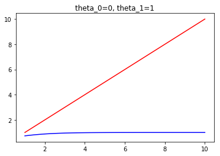

```python
import matplotlib.pyplot as plt
import numpy as np

x = np.linspace(1, 10, 100)

theta_0 = 0
theta_1 = 1
theta_x=theta_0+theta_1*x
f_theta_x=1/(1+np.exp(-theta_x))
logit_f_theta_x=theta_x
plt.title("theta_0=0, theta_1=1")
plt.plot(x,logit_f_theta_x,"r")
plt.plot(x,f_theta_x,"b")
```

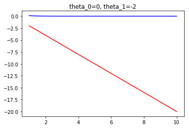

```python
theta_0 = 0
theta_1 = -2
theta_x=theta_0+theta_1*x
f_theta_x=1/(1+np.exp(-theta_x))
logit_f_theta_x=theta_x
plt.title("theta_0="+str(theta_0)+", theta_1="+str(theta_1))
plt.plot(x,logit_f_theta_x,"r")
plt.plot(x,f_theta_x,"b")
```

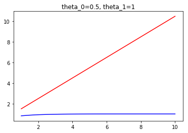

```python
theta_0 = 0.5
theta_1 = 1
theta_x=theta_0+theta_1*x
f_theta_x=1/(1+np.exp(-theta_x))
logit_f_theta_x=theta_x
plt.title("theta_0="+str(theta_0)+", theta_1="+str(theta_1))
plt.plot(x,logit_f_theta_x,"r")
plt.plot(x,f_theta_x,"b")
```

[figure not shown]

```python
theta_0 = 0
theta_1 = 0
theta_x=theta_0+theta_1*x
f_theta_x=1/(1+np.exp(-theta_x))
logit_f_theta_x=theta_x
plt.title("theta_0="+str(theta_0)+", theta_1="+str(theta_1))
plt.plot(x,logit_f_theta_x,"r")
plt.plot(x,f_theta_x,"b")
```

Easy to find $f\theta(x) ∼ logistic(\theta·x)=\beta X$, which means $\theta x$ defines a decision boundary. Also, the logit theta x function is monotonous, thus, $\theta_0+\theta_1*x$ is a linear seperating hyperplane.

### Exercise 6

For Normal Distribution with unknown mean and known variance, we have $$f(x_1,...x_n|\mu)=(2\pi)^{\frac{-n}{2}}\sigma^{-n}exp(\frac{-1}{2\sigma^2}\sum^n_{i=1}x_i^2+\frac{\mu}{\sigma^2}\sum^n_{i=1}x_i-\frac{n\mu^2}{2\sigma^2}).$$

So let $$\mu(x_1...x_n)=(2\pi)^{\frac{-n}{2}}\sigma^{-n}exp(\frac{-1}{2\sigma^2}\sum^n_{i=1}x_i^2),$$

we could also transform the function to $$v(k,\mu)=exp(-\frac{n\mu^2}{2\sigma^2}+\frac{\mu}{\sigma^2}k),$$

where $$k=\sum^n_{i=1}x_i.$$

By the factorization theorem this shows that k is a sufficient statistic.

### Exercise 7

(1) From the question we have:

1 ${X_i}^n_{i=1}$ be independent and identically distributed observations.

2 $X_1 = Z_1 + \theta, ..., X_n = Z_n + \theta$.

3 $min_i(X_i) = min_i(Z_i + \theta), max_i(X_i) = max_i(Z_i + \theta), where\space {Z_i}^n_{i=1}$ are independent and identically distributed observations from F(x).

So $R=max_i(X_i) - min_i(X_i)=max_i(Z_i) - min_i(Z_i)$ is irrelevant with local parameter. Which means R is ancilliary and not related with theta.

### Exercise 8

First, The $N(\mu, \sigma^2) \space family \space with \space \theta = (\mu, \sigma^2)$ is a 2pef with $$w(\theta)= (\frac{\mu}{\sigma^2},\frac{-1}{2\sigma^2}) , t(x)=(x,x^2).$$

In our case, $\mu=\sigma$.

Then $T(X) = (\sum^n_{i=1} X_i,\sum^n_{i=1}X_i^2)$ is the natural SS.

Then T(X) is a one-to-one function of $U(X) = (\bar x,s^2)$.

Let $g(x_1,x_2)=x_1^2-x_2$, then $$E(g(U))=E(\bar x^2-s^2)=\mu^2-mu^2=0.$$

However, g(U) is not trivially 0. So $N(\mu, \sigma^2)$ has a sufficient statistic but is not complete.

### Exercise 9

For Poisson distribution, $$p(x|\lambda)=\frac{\lambda^xe^{-\lambda}}{x!}\\ p(x|\lambda)=\frac{1}{x!}exp(xlog\lambda -\lambda),$$

Where $\eta = log\lambda, T(x) = x, A(\eta) = \lambda=e^\eta, h(x) =\frac{1}{x!}$. Problem proved.

### Exercise 10

From the property of regular exponential family we have $$B(\eta)=log\int_xh(x)e^{\eta T(X)}dx.$$

Thus, $$\frac{\partial B(\eta)}{\partial \eta_i}=E_i(T_i(X))=\frac{\int_xT_i(X)h(x)e^{\eta T(X)}dx}{\int_xh(x)e^{\eta T(X)}dx}.$$

Also, $$Cov_\eta(T_i(X),T_j(X))=E_\eta[T_i(X)T_j(X)]-E_\eta[T_i(X)]E_\eta[T_j(X)] \\ =\frac{\int_xT_i(X)T_j(X)h(x)e^{\eta T(X)}dx}{\int_xh(x)e^{\eta T(X)}dx}-\frac{\frac{\partial}{\partial \eta_i}*\frac{\partial }{\partial \eta_j}}{(\int_xh(x)e^{\eta T(X)}dx)^2}.$$

Easy to find $$\frac{\int_xT_i(X)T_j(X)h(x)e^{\eta T(X)}dx}{\int_xh(x)e^{\eta T(X)}dx}-\frac{\frac{\partial}{\partial \eta_i}*\frac{\partial}{\partial \eta_j}}{(\int_xh(x)e^{\eta T(X)}dx)^2}=\frac{\partial B(\eta)}{\partial \eta_i \partial \eta j}.$$

Problem proved.

### Exercise 11

Easy to know, $$X \sim \operatorname{Bin}(n,p).$$

Thus, $$E[X^2] = \operatorname{Var}(X) + E[X]^2= np(1-p) + n^2 p^2 = np(1-p+np).$$

In this case,$$E[{\hat p}^2]=\frac{1}{n^2} E[X^2]=\frac{p(1-p+np)}{n}.$$

By CLT and Delta Method, we have $$\sqrt{n}(\hat{p}-p) \overset{d}{\to} N(0,p(1-p)) \Rightarrow \\ \sqrt{n}(\hat{p}(1-\hat{p})-p(1-p)) \overset{d}{\to} N(0,p(1-p)(1-2p)^2).$$

Problem proved.

### Exercise 12

(1) $$H(X,Y)=-\sum_x\sum_yP(x,y)logP(x,y)=-2*(1/4*log2(1/4)+1/6*log2(1/6)+1/12*log2(1/12))=2.46$$

(2)

$$H(Y|X)=(-2*(1/4*log2(1/4)+3/4*log2(3/4))-1*log2(1/2))/3=0.87$$

(3)

$$H(X)=-\sum p(x)log(p(x))=1.58.$$

So $H(X,Y)=H(X)+H(Y|X)$.

### Exercise 13

$$\begin{align} H[x] = -\int_{-\infty}^{+\infty}N(x|\mu,\Sigma)\ln(N(x|\mu,\Sigma)) dx \\ = -E[\ln(N(x|\mu,\Sigma))]\\ = -E[\ln((2\pi)^{-\frac{D}{2}} |\Sigma|^{-\frac12} e^{-\frac12(x - \mu)^T\Sigma^{-1}(x - \mu)})] \\ = \frac{D}{2}\ln(2\pi) + \frac12\ln |\Sigma| + \frac12E[(x - \mu)^T\Sigma^{-1}(x - \mu)]. \end{align}$$

Simplify the formula, we have $$\begin{align} H[x] = \frac12\ln|\Sigma| + \frac{D}{2}(1 + \ln(2\pi)) \end{align},$$

where D is dimensionality of $x$.